# SRPA Replication in France

Author

Anonymous (for review)

Published

July 12, 2024

## 1 Preamble

This file contains all R code and output (e.g., data wrangling; analysis; visualizations) that I conducted for the working titled paper: “Victimogenic Beauty: Attractiveness and Sexual Victimization Risks among University Students” by AUTHORS.

If you are interested in learning about how I became involved in this paper and some preliminary exchanges that shaped the analytic decisions below, click the “Introductory Comments” link below to expand and view these contents. Otherwise, skip over it to loading R libraries and settings.

**Introductory Comments**

REDACTED PARAGRAPH (Anonymized for peer review)

After reading the initial draft of the front end, I asked if the data will be publicly available upon publication, if I would have access to the data to conduct analyses, and if I could review a copy of the preregistration to compare the preregistered plan with the reported measurements and analysis. AUTHOR affirmed all of the above.

I also recommended adding a correlation matrix and discussed the inclusion of the “number of lifetime sexual partners” (NLP), a proxy for sexual activity, as a covariate in regression models. The addition of this variable to the dataset and model represents an important difference between our original study and the current study. Yet, I questioned the appropriateness of conceptualizing NLP as a confounder that should be adjusted for via covariate stratification and, instead, suggested it might be more appropriately conceptualized and modeled as a mediator. Here was my exact comment:

> “The SRPA effect estimate is very small; sure, it is statistically significant, but that is due to the very large sample size. What is the bivariate correlation between SRPA and victimization, and between SRPA and NLP? You referred to NLP as a confounder but, as described, is it not a mediator instead (like time in public or other routine activities)? That is, do you assume that NLP causes SRPA, or SRPA causes NLP (or some alternative causal assumption)? If SRPA (as a proxy for attractiveness) causes more lifetime partners (proxy for sexual activity), then a mediation model is appropriate (like we used).”

My reasoning was based on our original causal model found in Figure 1 (2020, p.101652) and on AUTHOR’s first draft of the manuscript’s front end. Specifically, AUTHOR had argued:

> “The interpretation of the link between youth physical attractiveness and sexual victimization among students as a consequence of perpetrator’s selection of more gratifiable targets is challenged by the fact that physically attractive individuals may have different routine activities when compared to less attractive individuals. Possibly because they have a lower level of anxiety and neuroticism and a higher self-esteem and social status (Ciosta & Maestripieri, 2023; Feingold, 1992), physically attractive students have a larger number of friends (Gordon et al., 2013), spend more time in public places (Savolainen et al., 2020) and have on average more sexual interactions (Felson et al., 2021; Rhodes, Simmons, & Petrs, 2005). The risk of sexual victimization being related with individual’s prior sexual history and activity (Abbey et al., 1996; Himelein et al., 1994; Koss & Dinero, 1989; Schapanski et al., 2021; Synovitz, & Byrne, 2010), the attractivity-victimization link could therefore be the consequence of a mere differential exposure to situations involving sexual encounters by attractive individuals.”

The manuscript continued by stating:

> “Spending more time at more risky timing is a known risk factor for sexual victimization (Quigg et al. 2020). In a study based on a representative sample of Finnish youths, Savolainen, Brauer & Ellonen (2020) confirmed that attractive individuals had a riskier lifestyle (going more out for parties and at more risky timing), and this feature partially mediated the attractivity-sexual victimization relationship. However, victim’s sexual activity was not controlled in the study and may have contributed to the attractivity-victimization link.”

So, is sexual activity as measured by NLP a confounder or a mediator? For now, this is a theoretical question that requires us to make a causal assumption one way or the other. Sure, it is also an empirical question, but it is not one that can be answered with these data. Barring an explicit research design for identifying and estimating potential causal effects of the exposure (attractiveness) on the mediator (NLP), confounders and mediators are statistically indistinguishable. That is, inclusion of the NLP variable into a regression model would have the same consequence irrespective of whether it is in reality a mediator or a confounder of the SRPA-victimization relationship.

Hence, in my email reply to AUTHOR, I also offered the following suggestion:

> “In general, I would state the causal assumptions formally (e.g., in a directed acyclic graph), estimate appropriate model (e.g., indirect effects if appropriate; or, document confounding bias), and then discuss alternative interpretations from different plausible causal assumptions. It is fine if those additional models are not explicitly identified in your preregistration – just be transparent about what is confirmatory and what is exploratory (and, in this case, justified theoretically and follows precedent from replicated study).”

In reply, AUTHOR provided me with a copy of the preregistration and the data. The following represents my attempt to follow my suggestion above. I try to strike a balance between following the preregistration design while also presenting competing “confounding” and “mediating” causal assumptions, and demonstrating how these different assumptions affect interpretation of the findings.

## 2 Load libraries & set options

```r
library(here)
library(haven)
library(ggplot2)
library(tidyverse)
library(naniar)
library(dagitty)
library(ggdag)
library(ggraph)
library(ggdist)
library(gt)
library(gtExtras)
library(ggthemes)
library(gtools)
# library(summarytools)
library(modelsummary)
library(ggmosaic)
library(GGally)
library(viridis)
library(ggalluvial)
library(patchwork)
library(mediation)
library(CMAverse)
library(rstanarm)
library(brms)
library(bayesplot)
library(tidybayes)
library(marginaleffects)
library(parallelly)
library(ordPens)

# https://cran.r-project.org/bin/windows/Rtools/rtools40.html
# install.packages("cmdstanr",repos = c("https://mc-stan.org/r-packages/",
#                                       getOption("repos")))
# library(cmdstanr)
# cmdstanr::check_cmdstan_toolchain(fix = TRUE)
# check_cmdstan_toolchain()

#set default knit & scientific notation options
knitr::opts_chunk$set(echo=TRUE, warning=FALSE, message=FALSE, fig.align="center")
options(scipen = 999, digits = 2) #set global option to two decimals

# identify & set # of available cores
  # replaced parallel::detectCores()
  # https://www.jottr.org/2022/12/05/avoid-detectcores/
nCoresphys <- parallelly::availableCores(logical = FALSE)

theme_set(bayesplot::theme_default())
# options(mc.cores = parallelly::availableCores(logical=FALSE))
# options(mc.cores = 4, logical=FALSE)
  #alt: can specify exact number of cores desired here &/or in models/ppchecks

print("T/F: Root 'here()' folder contains subfolder 'Models'")
```

```
[1] "T/F: Root 'here()' folder contains subfolder 'Models'"
```

```r
#check for Models folder to save figures, create if one does not exist
ifelse(dir.exists(here("Models")), TRUE, dir.create(here("Models")))
```

```
[1] TRUE
```

## 3 FIG1: DAGs

The preregistration mentions stratifying on age as a potential confounder. It also mentions adjusting for general positive self-perceptions by stratifying on participant’s self-evaluations of intelligence (SRintel) and popularity (SRpopular).

Gender is identified as a possible moderator and calls for separate analyses for males and females. Thus, models using the full sample will stratify on gender, and subsequent models will generate gender-specific estimates.

The preregistration also identifies sexual activity, measured as the respondent’s reported number of lifetime sexual partners (nlp), as a possible confounder. However, it is unclear whether sexual activity would confound or mediate the potential effect of (self-reported) physical attractiveness (SRPA) on sexual victimization. For instance, sexual activity might confound this effect by causing heightened self-assessments and, thus, higher responses on SRPA items. However, higher physical attractiveness might also increase desirability and, likewise, might increase opportunities for and participation in sexual activity which, in turn, increases sexual victimization risks. These two alternative possibilities are demonstrated in DAGs below.

```r
#function to shorten arrows (edges)
# https://stackoverflow.com/questions/65420136/how-do-you-adjust-the-arrows-in-a-ggplot-of-a-ggdag
shorten_dag_arrows <- function(tidy_dag, proportion){
# Update underlying ggdag object
tidy_dag$data <- dplyr::mutate(tidy_dag$data,
                             xend = (1-proportion/2)*(xend - x) + x,
                             yend = (1-proportion/2)*(yend - y) + y,
                             xstart = (1-proportion/2)*(x - xend) + xend,
                             ystart = (1-proportion/2)*(y-yend) + yend)
return(tidy_dag)
}

################
# DAG 1 (NLP as confounder)

DAG1 <- dagify(
  Y ~ A + M + C,
  A ~ M + C,
  exposure = "A",
  outcome = "Y",
  coords=list(
    x=c(A=1, M=1.5, Y=2, C=1.5),
    y=c(A=1, M=2, Y=1, C=3)
  )) %>% tidy_dagitty() %>%
  dplyr::mutate(covar = if_else(name == "C",
                                  "grey", "darkslategrey"),
                covar = if_else(name == "M",
                                  "maroon", covar)
                )


#function to shorten arrows - set percentage to shorten
DAG1p <- shorten_dag_arrows(DAG1, 0.25)

#create factor variable to isolate edge of interest, permits specifying edge color
testdat <- DAG1p %>% dplyr::mutate(
  myedge1 = if_else(DAG1p$data$name == "A" & DAG1p$data$to == "Y",
                    "focal", "other"),
  modlinetype = ifelse(myedge1 == "focal", "dashed", "solid")
  )


DAG1p2 <- testdat %>% ggplot(aes(x=x, y=y, xend=xend, yend=yend)) +
  geom_dag_edges(aes(x = xstart, y = ystart,
                     edge_color=myedge1,
                     edge_linetype = modlinetype), show.legend = FALSE) +
  geom_dag_text(label=c("Physically\nAttractive\n(SRPA)",
                        "Measured\nConfounders\n(E.g., Gender)",
                        "# of Lifetime\nSexual Partners\n(NLP)",
                        "Victimiz."),
                aes(color=covar), size=4) +
  theme_dag() +
  guides(fill = 'none', color = 'none', edge_color = 'none') +
  scale_color_manual(values = c("darkslategrey","grey", "maroon")) +
  scale_edge_colour_manual(values=c("darkslategrey","grey")) +
  scale_x_continuous(expand=expansion(mult=c(0.3,0.3))) +
  scale_y_continuous(expand=expansion(mult=c(0.3,0.3))) +
  annotate("text", x = -Inf, y = Inf, label = paste("DAG 1"), vjust = 4, hjust = -.2) +
  # annotate("text", x = -Inf, y = Inf, label = paste("DAG 1"), vjust = 7, hjust = -2)
  # ggtitle("DAG 1") +
  theme(plot.title = element_text(size = 14))


################
# DAG 2 (NLP as mediator)

DAG2 <- dagify(
  Y ~ A + M + C,
  M ~ A + C,
  A ~ C,
  exposure = "A",
  outcome = "Y",
  coords=list(
    x=c(A=1, M=1.5, Y=2, C=1.5),
    y=c(A=1, M=2, Y=1, C=3)
  )) %>% tidy_dagitty() %>%
  dplyr::mutate(covar = if_else(name == "C",
                                  "grey", "darkslategrey"),
                covar = if_else(name == "M",
                                  "maroon", covar)
                )


#function to shorten arrows - set percentage to shorten
DAG2p <- shorten_dag_arrows(DAG2, 0.25)

#create factor variable to isolate edge of interest, permits specifying edge color
testdat <- DAG2p %>% dplyr::mutate(
  myedge1 = if_else(DAG2p$data$name == "A" & DAG2p$data$to == "M" |
                      DAG2p$data$name == "M" & DAG2p$data$to == "Y" |
                      DAG2p$data$name == "A" & DAG2p$data$to == "Y",
                    "focal", "other"),
  modlinetype = ifelse(myedge1 == "focal", "dashed", "solid")
  )


DAG2p2 <- testdat %>% ggplot(aes(x=x, y=y, xend=xend, yend=yend)) +
  geom_dag_edges(aes(x = xstart, y = ystart,
                     edge_color=myedge1,
                     edge_linetype = modlinetype), show.legend = FALSE) +
  geom_dag_text(label=c("Physically\nAttractive\n(SRPA)",
                        "Measured\nConfounders\n(E.g., Gender)",
                        "# of Lifetime\nSexual Partners\n(NLP)",
                        "Victimiz."),
                aes(color=covar), size=4) +
  theme_dag() +
  guides(fill = 'none', color = 'none', edge_color = 'none') +
  scale_color_manual(values = c("darkslategrey","grey", "maroon")) +
  scale_edge_colour_manual(values=c("darkslategrey","grey")) +
  scale_x_continuous(expand=expansion(mult=c(0.3,0.3))) +
  scale_y_continuous(expand=expansion(mult=c(0.3,0.3))) +
  annotate("text", x = -Inf, y = Inf, label = paste("DAG 2"), vjust = 4, hjust = -.2) +
  # annotate("text", x = -Inf, y = Inf, label = paste("DAG 2"), vjust = 5, hjust = -.5)
  # ggtitle("DAG 2") +
  theme(plot.title = element_text(size = 14))

# ggsave("DAG1.jpeg", DAG1p2)
# ggsave("DAG2.jpeg", DAG2p2)
```

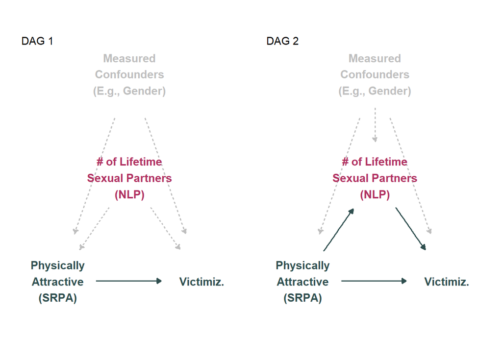

Figure 1. DAGs illustrating assumed causal relationship between self-reported physical attractiveness and victimization, with sexual activity (number of lifetime sexual partners) as a confounder (DAG 1) or mediator (DAG 2)

As a result of this ambiguity, initial models will estimate SRPA effects with and without stratifying on nlp to assess the potential total and net effects after adjusting for confounding and/or mediating effects. Exploratory models will also present estimates of indirect effects; these should be interpreted with caution given the unclear role and lack of precise causal identification.

## 4 Data

### 4.1 Description of variables

I received an SPSS datafile containing the relevant items needed to conduct the analysis. The file I received appears to be a raw subset of a much larger database containing survey responses of university students in France. In his initial drafts, AUTHOR had retained as eligible participants only males and female university students (dropping non-students and those who did not answer the student status question). He had also removed those who failed two attention checks. Specifically, participants were asked if they gave accurate answers at the beginning of the questionnaire and at the very end; unreliable responses and non-responses were dropped.

### 4.2 Read, Wrangle, & Skim Data

**Read SPSS Data into R**

```r
# datv3 <- read_spss(here('GratifpaperV3.sav'))
datv3 <- read_spss(here('Gratif_LBS_JB.sav'))
head(datv3) %>% gt()
```

| Q3. Selon l'état civil à la naissance, quel est votre sexe ? | Q5. Quel est votre âge ? | Q10. Êtes-vous actuellement étudiant.e ? | Q17. Avez-vous une activité rémunérée pour subvenir à vos études (hors stage) ? | Q721. Si vous avez commencé le questionnaire « juste pour voir » et avez répondu de manière très approximative ou inexacte, pouvez-vous le préciser ? Jusqu’à présent, j’ai répondu de manière précise e… | Q115. Les questions suivantes portent sur votre vie affective et sexuelle. Avez-vous déjà eu un rapport sexuel ? | Q117. Avec combien de partenaires en tout avez-vous eu au moins un rapport sexuel ? | Q331 Depuis que vous êtes étudiant.e dans l’enseignement supérieur, est-ce que quelqu’un a tenté contre votre volonté de vous faire l’une des choses suivantes, mais sans y parvenir : Vous embrasser, t… | Q368 Depuis que vous êtes étudiant.e dans l’enseignement supérieur, est-ce que quelqu’un vous a effectivement fait contre votre volonté l’une des choses suivantes : Vous embrasser, toucher la poitrine… | Q148 Depuis que vous êtes étudiant.e dans l’enseignement supérieur, est-ce que quelqu’un a tenté contre votre volonté de vous faire l’une des choses suivantes, mais sans y parvenir : Pénétration sexue… | Q405 Depuis que vous êtes étudiant.e dans l’enseignement supérieur, est-ce que quelqu’un vous a effectivement fait contre votre volonté l’une des choses suivantes : Pénétration sexuelle (quand une per… | Q81 Intelligente | Q82 Populaire, ma compagnie est recherchée | Q83 Physiquement séduisant.e | Q85 Attirant.e., remarqué.e pour sa beauté physique | Q765 Pouvez-vous confirmer que vous avez répondu aussi sincèrement que possible à cette étude (si vous répondez "non", vous pourrez tout de même participer au tirage au sort et recevoir les résultats)… | Q84 Fort.e physiquement, musclé.e, puissant.e |
| --- | --- | --- | --- | --- | --- | --- | --- | --- | --- | --- | --- | --- | --- | --- | --- | --- |
| 1 | 23 | Oui | Non | Oui | Oui | NA | 1 | 1 | 1 | 1 | 7 | 7 | 7 | 7 | 1 | 7 |
| NA | NA | NA | NA | NA | NA | NA | NA | NA | NA | NA | NA | NA | NA | NA | NA | NA |
| 2 | 21 | Oui | Non | Oui | Non | NA | 0 | 0 | 0 | 0 | 6 | 6 | 4 | 4 | 1 | 4 |
| 2 | 18 | Oui | Oui | Oui | Oui | 3 | 0 | 0 | 0 | 0 | 5 | 3 | 5 | 4 | NA | 4 |
| 2 | 18 | Oui | Non | Oui | Oui | NA | NA | NA | NA | NA | NA | NA | NA | NA | NA | NA |
| NA | NA | Oui | NA | Oui | Oui | NA | NA | NA | NA | NA | NA | NA | NA | NA | NA | NA |

**Data wrangling**

```r
# ChecK1: Approximate translation: "Q10. Are you currently a student?" Retain affirmative responses ("Oui")

# CHECK2: Approx. translation: "Q721. If you started the questionnaire “just to see” and answered very roughly or inaccurately, can you clarify this? So far I have responded precisely and accurately." Retain participants who responded affirmatively ("Oui") that they have responded precisely and accurately

# Q765_final_check: Approx. translation: "Q765 Can you confirm that you responded as truthfully as possible to this study (if you answer "no", you will still be able to participate in the draw and receive the results)?" Drop disconfirming ("3") responses.

#initial N=86,426 rows
datv3 <- datv3 %>%
  zap_labels %>%
  zap_label %>%
  dplyr::filter(ChecK1 == "Oui") %>%  #N=77,597 (dropped n=8,829 non-students)
  dplyr::filter(CHECK2 == "Oui") %>%  #N=73,093 (dropped n=4,504 initial attn check)
  dplyr::filter(Q765_final_check %in% c(1,2)) %>%  #N=55,786 (dropped n=17,307 reportedly "unreliable" [=3, n=89] or missing a response [NA, n=17,218] on final attn check)
  dplyr::filter(Gender_HF %in% c("1","2")) %>% #dropped N=240 not reporting M/F sex on birth records (neither: n=44; don't know: n=22; don't wish to answer: n=163; NA: n=11)
  rename(
    sexvic1 = Q331_Attempt_sexual_touch_Vict1,
    sexvic2 = Q368_Sexual_touch_Vict2,
    sexvic3 = Q148_Attempt_rape_Vict3,
    sexvic4 = Q405_Rape_Vict4,
    SRPA1 = Q83_physically_seducing_SRPA1,
    SRPA2 = Q85_Attractive_SRPA2,
    nlp = Lifetime_N_sex_partners,
    age = Age
  ) %>%
  mutate(
    nlp = if_else(Ever_sexual_intercourse == "Non", 0, nlp), #skip pattern to replace NA with "0" sex partners for valid observations
    eversex = if_else(Ever_sexual_intercourse == "Oui", "1", Ever_sexual_intercourse),
    eversex = if_else(Ever_sexual_intercourse == "Non", "0", eversex)
    ) %>%
  mutate(
    sexvicsum = sexvic1 + sexvic2 + sexvic3 + sexvic4,
    SRPAavg = (SRPA1 + SRPA2)/2,
    SRPA95 = as_factor(if_else(
      SRPAavg >= quantile(SRPAavg, probs = 0.95, na.rm = TRUE), 1, 0)),
    gender = as_factor(Gender_HF),
    worked = as_factor(if_else(Q17_work_during_studies %in% "Je ne réponds pas",
                               NA, Q17_work_during_studies)),
    worked = if_else(worked == "Oui", "1", worked),
    worked = if_else(worked == "Non", "0", worked),
    agez = as.numeric(scale(age)),
    SRintelz = as.numeric(scale(Q81_intelligent)),
    SRpopularz = as.numeric(scale(Q82_popular)),
    SRmuscularz = as.numeric(scale(Q84_Strong_muscular)),
    SRPAavgz = as.numeric(scale(SRPAavg)),
    nlpz = as.numeric(scale(nlp)),
    sexvicsumf = factor(sexvicsum, ordered=TRUE, levels = c(0, 1, 2, 3, 4)),
    nlpf = factor(nlp, ordered=TRUE, levels = c(0,1,2,3,4,5,6,7,8,9))
  )

# Note: stdzing cols using scale() generates a matrix col w/in df
# This causes problems (e.g., w/avg_comparisons())
# One solution is to wrap in as.numeric() to convert back to numeric vector
  # class(datv3$age)
# https://stackoverflow.com/questions/70377294/why-does-mutateacross-with-scale-add-1-to-the-column-header

head(datv3) %>% gt()
```

| Gender_HF | age | ChecK1 | Q17_work_during_studies | CHECK2 | Ever_sexual_intercourse | nlp | sexvic1 | sexvic2 | sexvic3 | sexvic4 | Q81_intelligent | Q82_popular | SRPA1 | SRPA2 | Q765_final_check | Q84_Strong_muscular | eversex | sexvicsum | SRPAavg | SRPA95 | gender | worked | agez | SRintelz | SRpopularz | SRmuscularz | SRPAavgz | nlpz | sexvicsumf | … |
| --- | --- | --- | --- | --- | --- | --- | --- | --- | --- | --- | --- | --- | --- | --- | --- | --- | --- | --- | --- | --- | --- | --- | --- | --- | --- | --- | --- | --- | --- | --- |
| 1 | 23 | Oui | Non | Oui | Oui | NA | 1 | 1 | 1 | 1 | 7 | 7 | 7 | 7 | 1 | 7 | 1 | 4 | 7.0 | 1 | 1 | 0 | 0.45 | 1.59 | 2.53 | 2.547 | 2.33 | NA | 4 | … |
| 2 | 21 | Oui | Non | Oui | Non | 0 | 0 | 0 | 0 | 0 | 6 | 6 | 4 | 4 | 1 | 4 | 0 | 0 | 4.0 | 0 | 2 | 0 | -0.06 | 0.66 | 1.81 | 0.619 | 0.18 | -0.872 | 0 | … |
| 2 | 19 | Oui | Non | Oui | Oui | 1 | 0 | 0 | 0 | 0 | 5 | 5 | 2 | 2 | 1 | 2 | 1 | 0 | 2.0 | 0 | 2 | 0 | -0.57 | -0.27 | 1.09 | -0.666 | -1.26 | -0.404 | 0 | … |
| 2 | 19 | Oui | Non | Oui | Oui | 2 | 0 | 0 | 0 | 0 | 5 | 4 | 3 | 2 | 1 | 3 | 1 | 0 | 2.5 | 0 | 2 | 0 | -0.57 | -0.27 | 0.37 | -0.024 | -0.90 | 0.063 | 0 | … |
| 2 | 17 | Oui | Non | Oui | Non | 0 | 0 | 0 | 0 | 0 | 6 | 2 | 4 | 5 | 1 | 4 | 0 | 0 | 4.5 | 0 | 2 | 0 | -1.08 | 0.66 | -1.07 | 0.619 | 0.53 | -0.872 | 0 | … |
| 2 | 19 | Oui | Non | Oui | Non | 0 | 0 | 0 | 0 | 0 | 5 | 2 | 2 | 2 | 1 | 3 | 0 | 0 | 2.0 | 0 | 2 | 0 | -0.57 | -0.27 | -1.07 | -0.024 | -1.26 | -0.872 | 0 | … |

**Skim data**

Unique

Missing Pct.

Mean

SD

Min

Median

Max

Histogram

Gender_HF

2

0

1.7

0.5

1.0

2.0

2.0

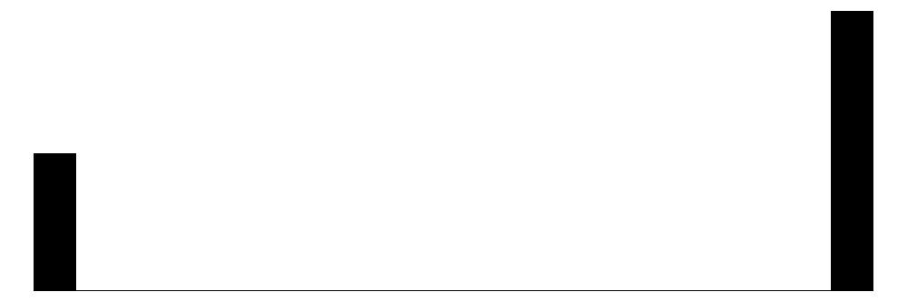

age

49

0

21.2

3.9

16.0

20.0

65.0

[figure not shown]

nlp

11

9

1.9

2.1

0.0

1.0

9.0

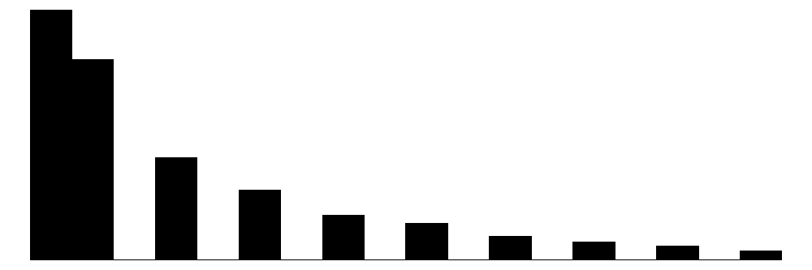

sexvic1

3

1

0.2

0.4

0.0

0.0

1.0

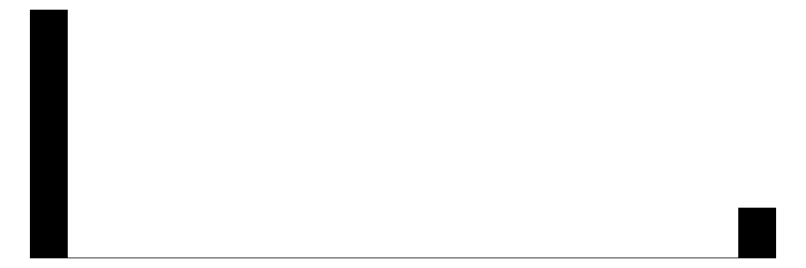

sexvic2

3

2

0.1

0.3

0.0

0.0

1.0

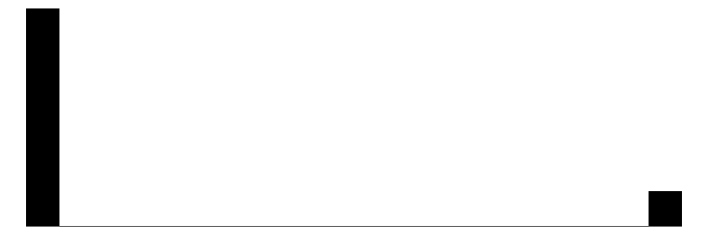

sexvic3

3

1

0.0

0.2

0.0

0.0

1.0

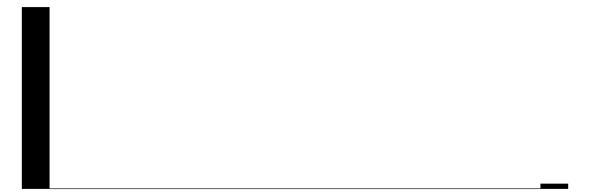

sexvic4

3

2

0.0

0.2

0.0

0.0

1.0

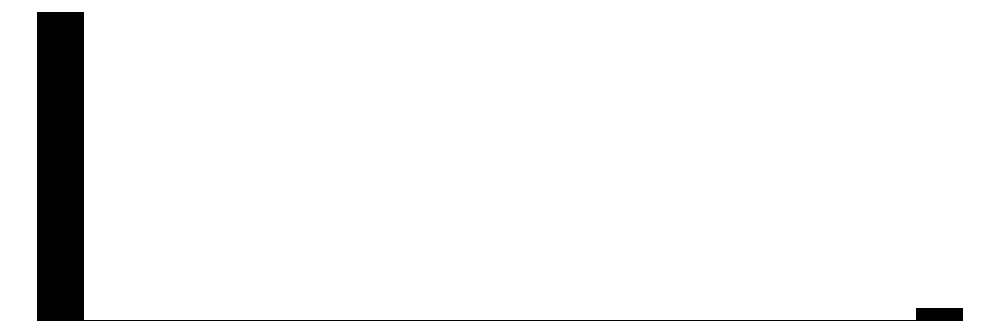

Q81_intelligent

8

0

5.3

1.1

1.0

5.0

7.0

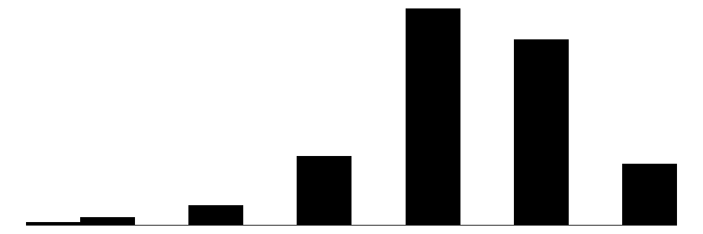

Q82_popular

8

0

3.5

1.4

1.0

4.0

7.0

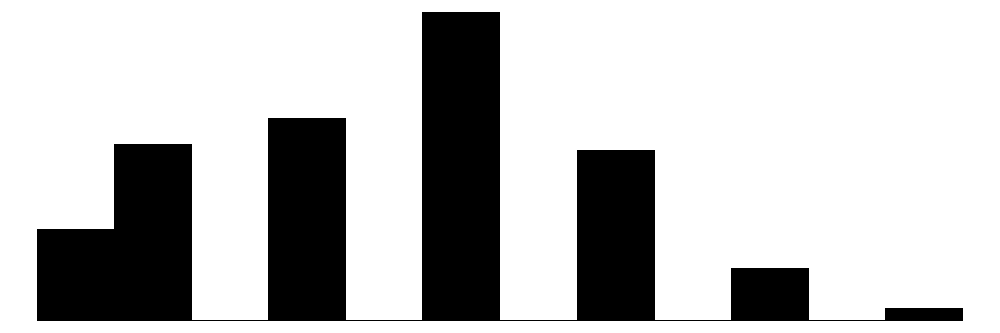

SRPA1

8

0

4.0

1.4

1.0

4.0

7.0

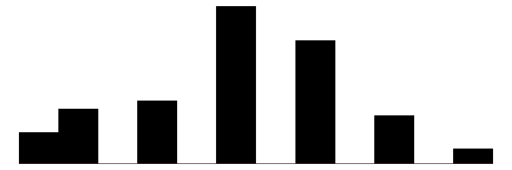

SRPA2

8

0

3.5

1.5

1.0

4.0

7.0

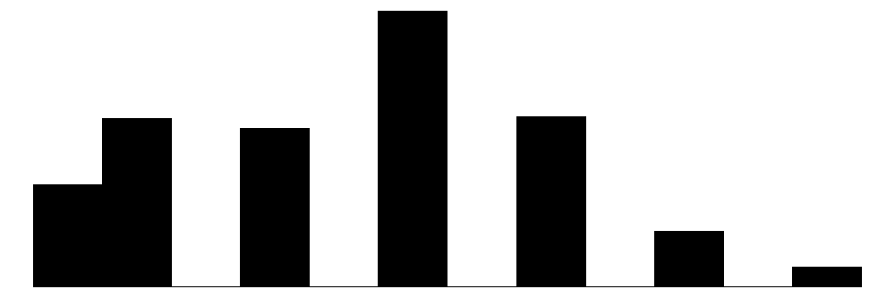

Q84_Strong_muscular

8

0

3.0

1.6

1.0

3.0

7.0

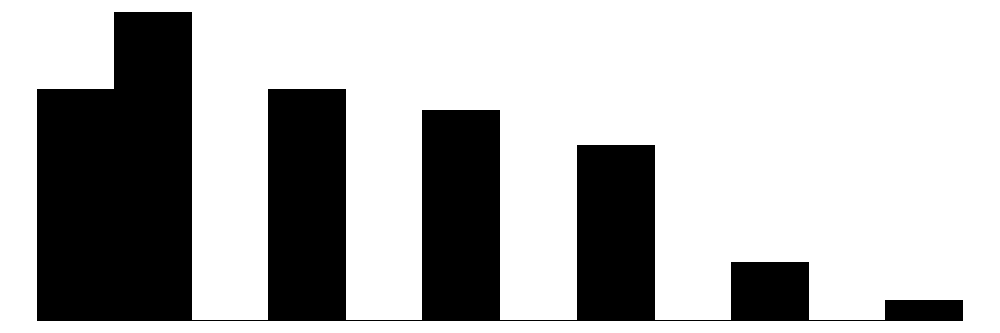

sexvicsum

6

5

0.3

0.8

0.0

0.0

4.0

[8 more figures not shown]

N

%

Oui

55546

100.0

Q17_work_during_studies

Je ne réponds pas

642

1.2

Non

38773

69.8

Oui

16049

28.9

NA

82

0.1

Oui

55546

100.0

Ever_sexual_intercourse

Non

16412

29.5

Oui

39043

70.3

NA

91

0.2

Q765_final_check

1

52059

93.7

2

3487

6.3

eversex

0

16412

29.5

1

39043

70.3

NA

91

0.2

SRPA95

0

51434

92.6

1

3975

7.2

gender

1

18293

32.9

2

37253

67.1

worked

0

38773

69.8

1

16049

28.9

NA

724

1.3

sexvicsumf

0

42378

76.3

1

4849

8.7

2

4220

7.6

3

996

1.8

4

546

1.0

nlpf

0

16412

29.5

1

13158

23.7

2

6742

12.1

3

4565

8.2

4

2922

5.3

5

2423

4.4

6

1534

2.8

7

1176

2.1

8

898

1.6

9

583

1.0

```r
datasummary_skim(datv3)
```

```r
# cor(datv3$SRPA1,datv3$SRPA2, use="complete.obs")
# psych::alpha(datv3[,c("sexvic1","sexvic2", "sexvic3","sexvic4")])
```

### 4.3 Missingness

After filtering on student status, gender (M/F), and data quality checks for reliable survey completers, this data file contains survey responses from N=55,546 eligible male and female students who passed two attention checks (out of 86,426 initial rows from Qualtrics). Let’s take a look at remaining missing data patterns among responses from eligible participants on variables we will use in analyses.

**Visualize missingness**

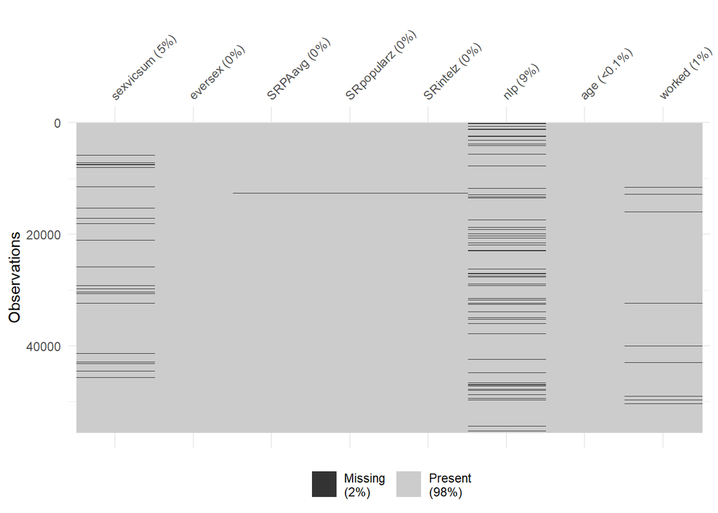

```r
# https://cran.r-project.org/web/packages/naniar/vignettes/naniar-visualisation.html
datv3 %>%
  dplyr::select(c(sexvicsum, eversex, SRPAavg, SRpopularz, SRintelz, nlp,
                  age, worked)) %>%
  vis_miss()
```

**Count NAs**

```r
datv3 %>%
  dplyr::select(c(sexvicsum, eversex, SRPAavg, SRpopularz, SRintelz, nlp,
                  age, worked, gender)) %>%
  summarise_all(funs(sum(is.na(.))))
```

```
# A tibble: 1 × 9
  sexvicsum eversex SRPAavg SRpopularz SRintelz   nlp   age worked gender
      <int>   <int>   <int>      <int>    <int> <int> <int>  <int>  <int>
1      2557      91     137        103       85  5133    29    724      0
```

**% Missing**

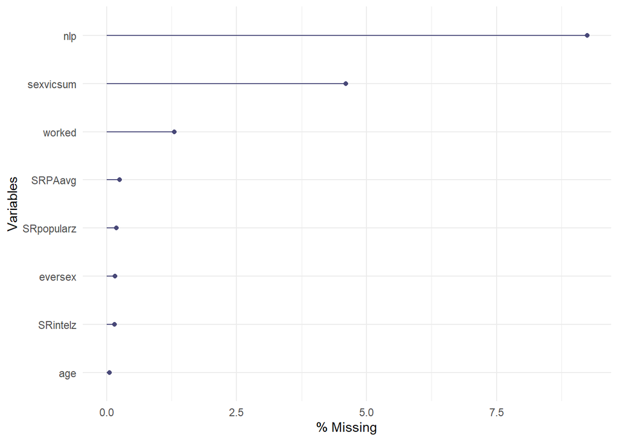

```r
datv3 %>%
  dplyr::select(c(sexvicsum, eversex, SRPAavg, SRpopularz, SRintelz, nlp,
                  age, worked)) %>%
  gg_miss_var(show_pct = TRUE)
```

**% Missing by SRPAavg**

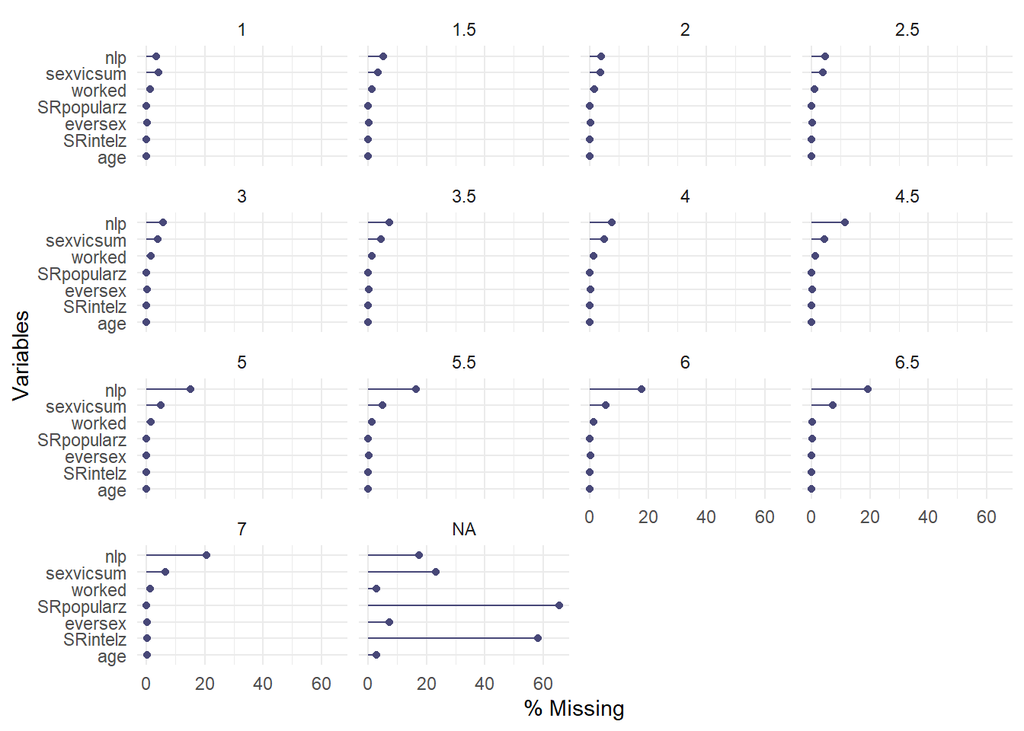

```r
datv3 %>%
  dplyr::select(c(sexvicsum, eversex, SRPAavg, SRpopularz, SRintelz, nlp,
                  age, worked)) %>%
  gg_miss_var(facet = SRPAavg, show_pct = TRUE)
```

**% Missing by sexvicsum**

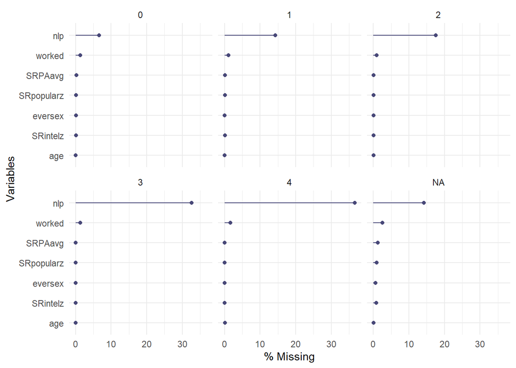

```r
datv3 %>%
  dplyr::select(c(sexvicsum, eversex, SRPAavg, SRpopularz, SRintelz, nlp,
                  age, worked)) %>%
  gg_miss_var(facet = sexvicsum, show_pct = TRUE)
```

**Summary stats (Victimiz, SRPA) by NLP missing/not missing (!NA)**

```r
shadowdat <- bind_shadow(datv3)
datv3 %>%
  bind_shadow() %>%
  group_by(nlp_NA) %>%
  summarise_at(.vars = c("sexvicsum", "SRPAavg"),
               .funs = c("mean", "sd", "var", "min", "max"),
               na.rm = TRUE)
```

```
# A tibble: 2 × 11
  nlp_NA sexvicsum_mean SRPAavg_mean sexvicsum_sd SRPAavg_sd sexvicsum_var
  <fct>           <dbl>        <dbl>        <dbl>      <dbl>         <dbl>
1 !NA             0.301         3.69        0.724       1.38         0.524
2 NA              0.827         4.43        1.17        1.30         1.37
# ℹ 5 more variables: SRPAavg_var <dbl>, sexvicsum_min <dbl>,
#   SRPAavg_min <dbl>, sexvicsum_max <dbl>, SRPAavg_max <dbl>
```

**Distribution of Victimiz by NLP missing**

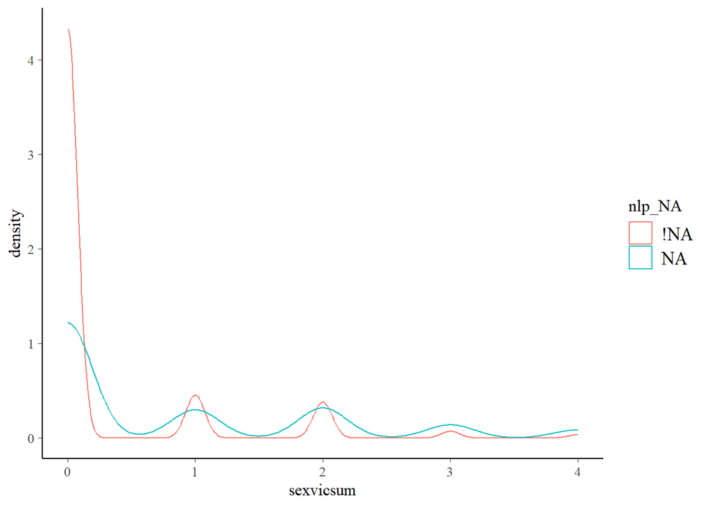

```r
ggplot(shadowdat,
       aes(x = sexvicsum,
           colour = nlp_NA)) +
  geom_density()
```

**Distribution of SRPA by NLP missing**

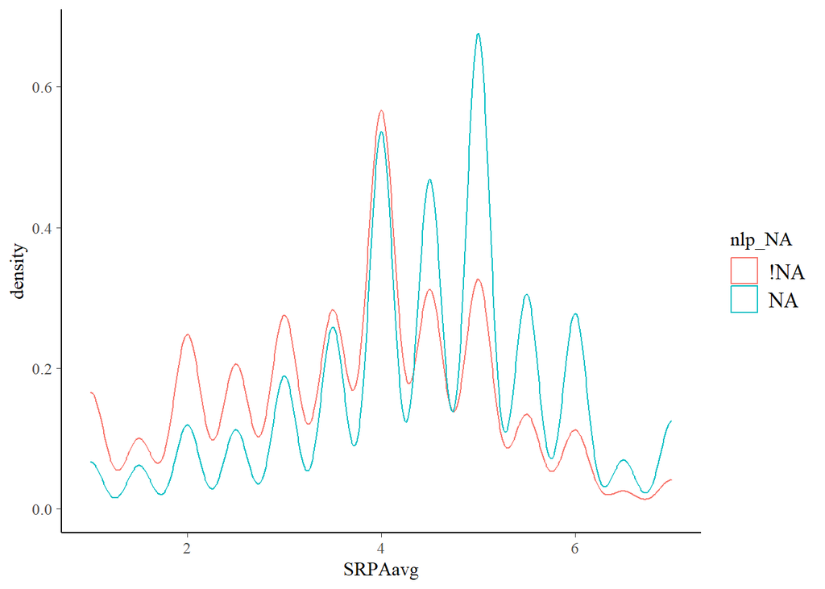

```r
ggplot(shadowdat,
       aes(x = SRPAavg,
           colour = nlp_NA)) +
  geom_density()
```

**Xtab sexvicsum by NLPmiss**

```r
table(shadowdat$sexvicsum, shadowdat$nlp_NA)
```

```
      !NA    NA
  0 39564  2814
  1  4157   692
  2  3480   740
  3   671   325
  4   346   200
```

```r
prop.table(table(shadowdat$sexvicsum, shadowdat$nlp_NA), margin=2)
```

```
       !NA     NA
  0 0.8205 0.5898
  1 0.0862 0.1450
  2 0.0722 0.1551
  3 0.0139 0.0681
  4 0.0072 0.0419
```

Among eligible survey completers, missingness rates were negligible or low for most variables, and missingness on all but NLP did not appear to vary systematically across levels of our key DV or IV. Full information or casewise deletion approaches should be appropriate for most of these variables.

Yet, most of the 5,133 participants that did not report on the number of life partners did report on the previous skip pattern variable indicating any past sexual activity; that variable had only n=91 (0.16%) missing observations.

So, I will remove rows with missing data on all study variables except NLP, then conduct complete case analysis when including NLP (dropping NA values). Given the potentially biasing missingness patterns on this variable, I will also conduct sensitivity analyses using the more crudely measured yet more completely reported dichotomous “sexual activity” variable instead.

```r
datv3 <- datv3 %>% drop_na(SRPAavg, sexvicsum, age, worked, gender,
                  SRpopularz, SRintelz)

datv3sub <- datv3 %>%
  mutate(workedn = as.numeric(worked)) %>%
  dplyr::select(c(SRPAavg, sexvicsum, nlp, eversex, age, Gender_HF, workedn,
                  SRpopularz, SRintelz))
```

## 5 Basic descriptives

### 5.1 Univariate statistics

**Skim analytic sample data**

Unique

Missing Pct.

Mean

SD

Min

Median

Max

Histogram

SRPAavg

13

0

3.7

1.4

1.0

4.0

7.0

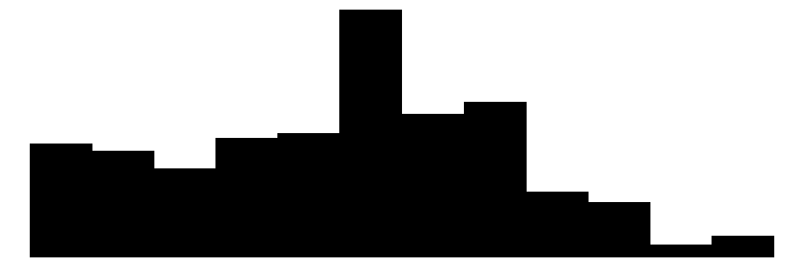

sexvicsum

5

0

0.3

0.8

0.0

0.0

4.0

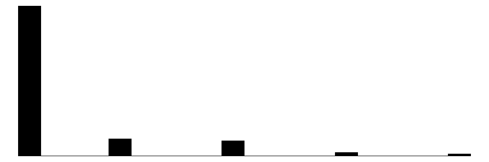

nlp

11

9

1.8

2.1

0.0

1.0

9.0

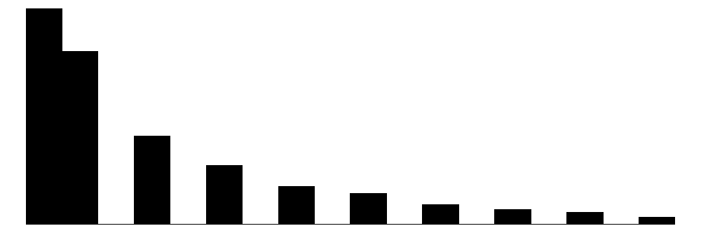

age

48

0

21.2

3.9

16.0

20.0

65.0

[figure not shown]

Gender_HF

2

0

1.7

0.5

1.0

2.0

2.0

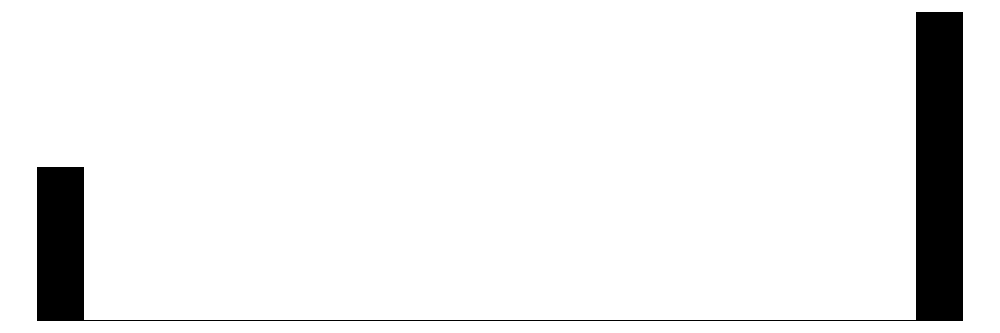

workedn

2

0

0.3

0.5

0.0

0.0

1.0

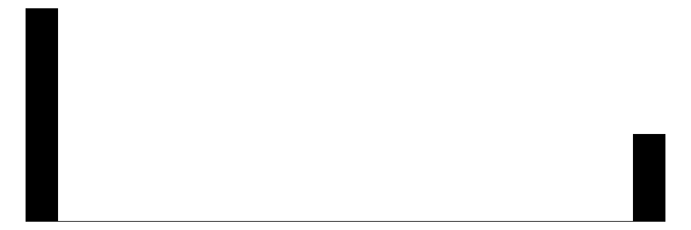

SRpopularz

7

0

0.0

1.0

-1.8

0.4

2.5

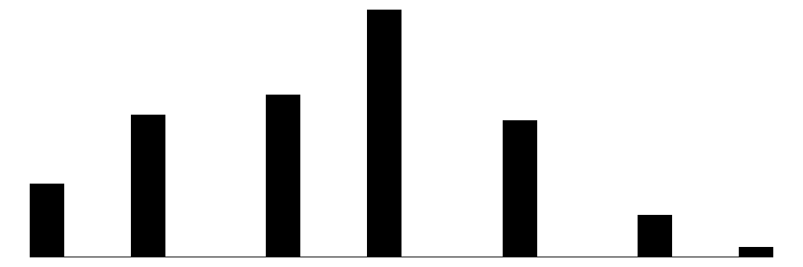

SRintelz

7

0

0.0

1.0

-4.0

-0.3

1.6

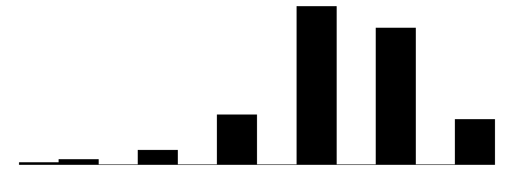

eversex

N

%

0

15562

29.8

1

36565

70.1

NA

64

0.1

```r
datasummary_skim(datv3sub)
```

**Correlation SRPA items**

```r
cor(datv3$SRPA1,datv3$SRPA2, use="complete.obs")
```

```
[1] 0.82
```

**Cronbach’s alpha victimization**

```r
psych::alpha(datv3[,c("sexvic1","sexvic2", "sexvic3","sexvic4")])$total
```

```
 raw_alpha std.alpha G6(smc) average_r S/N    ase  mean  sd median_r
      0.68      0.71    0.69      0.38 2.4 0.0019 0.087 0.2     0.34
```

### 5.2 Traditional correlations

**Correlation heatmap**

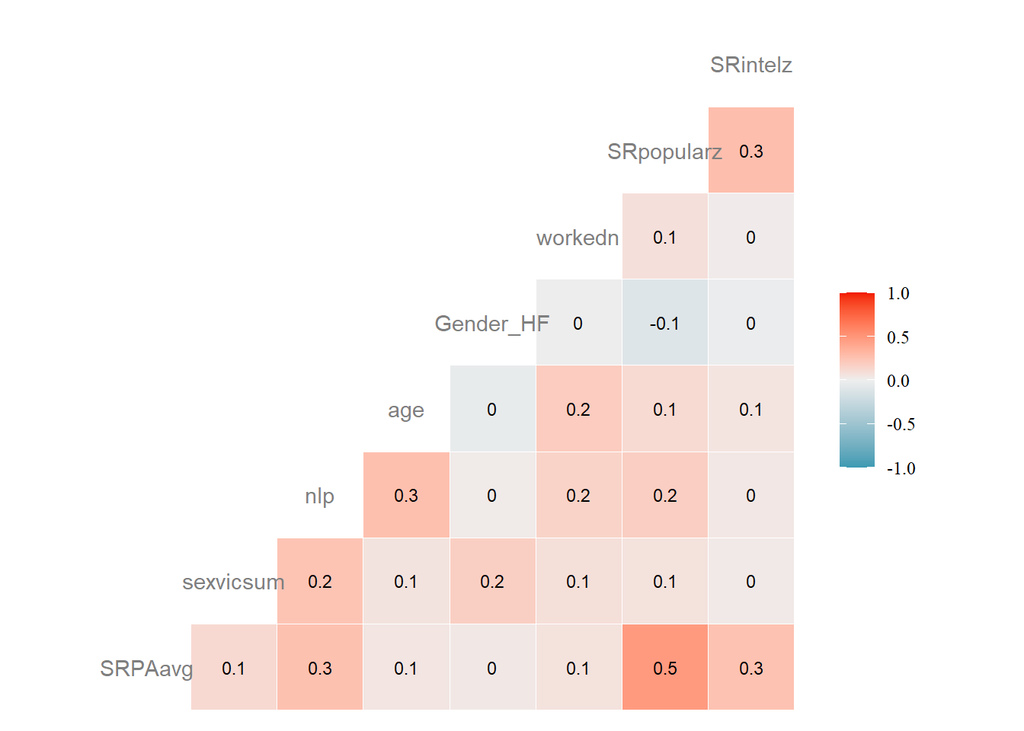

```r
# https://www.guru99.com/r-pearson-spearman-correlation.html

ggcorr(datv3sub,
       digits = 2,
       label = TRUE,
       label_size = 3,
       color = "grey50")
```

**Pairs plot**

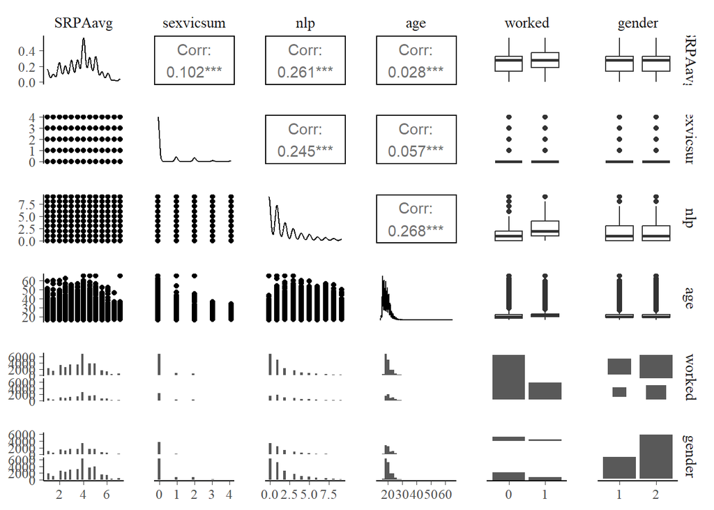

```r
datv3sub <- datv3 %>%
  dplyr::select(c(SRPAavg, sexvicsum, nlp, age, worked, gender))

datv3sub %>% drop_na() %>%
  ggpairs()
```

**Pairs plot grouped by gender**

Preregistration stated expectation that predicted correlations would be stronger for girls compared to boys. So, here are initial bivariate correlations grouped by gender.

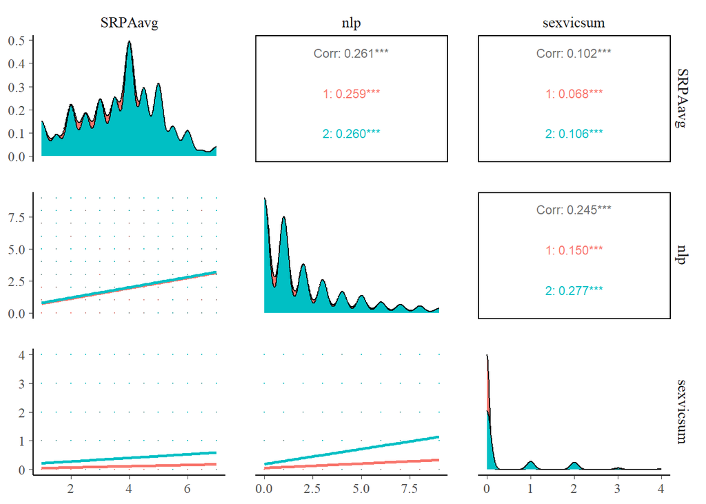

```r
pairsgen <- datv3sub %>% drop_na() %>%
  mutate(gender = as_factor(gender)) %>%
  ggpairs(columns = c("SRPAavg", "nlp", "sexvicsum"),
        upper = list(continuous = wrap("cor", size = 3)),
        lower = list(continuous = wrap("smooth", alpha = 0.3, size = 0.1)),
        mapping = aes(color = gender)
        )
pairsgen
```

**Pearson/Spearman matrix (select vars)**

```r
#Pearsons r & Spearman
datasummary_correlation(datv3sub, method="pearspear")
```

|  | SRPAavg | sexvicsum | nlp | age |
| --- | --- | --- | --- | --- |
| SRPAavg | 1 | .12 | .26 | .05 |
| sexvicsum | .13 | 1 | .24 | .07 |
| nlp | .29 | .23 | 1 | .27 |
| age | .07 | .14 | .30 | 1 |

**Pearson/Spearman matrix (full dataset)**

```r
datasummary_correlation(datv3, method="pearspear")
```

|  | Gender_HF | age | nlp | sexvic1 | sexvic2 | sexvic3 | sexvic4 | Q81_intelligent | Q82_popular | SRPA1 | SRPA2 | Q84_Strong_muscular | sexvicsum | SRPAavg | agez | SRintelz | SRpopularz | SRmuscularz | SRPAavgz | nlpz |
| --- | --- | --- | --- | --- | --- | --- | --- | --- | --- | --- | --- | --- | --- | --- | --- | --- | --- | --- | --- | --- |
| Gender_HF | 1 | -.04 | .03 | .17 | .15 | .07 | .10 | -.02 | -.10 | .03 | .03 | -.19 | .18 | .03 | -.04 | -.02 | -.10 | -.19 | .03 | .03 |
| age | -.05 | 1 | .27 | .05 | .06 | .04 | .05 | .06 | .12 | .06 | .04 | .04 | .07 | .05 | 1.00 | .06 | .12 | .04 | .05 | .27 |
| nlp | .03 | .30 | 1 | .19 | .20 | .13 | .18 | .04 | .18 | .27 | .23 | .11 | .24 | .26 | .27 | .04 | .18 | .11 | .26 | 1.00 |
| sexvic1 | .17 | .11 | .19 | 1 | .61 | .23 | .25 | .03 | .07 | .11 | .10 | -.01 | .83 | .11 | .05 | .03 | .07 | -.01 | .11 | .19 |
| sexvic2 | .15 | .12 | .19 | .61 | 1 | .29 | .38 | .03 | .06 | .10 | .09 | -.02 | .86 | .10 | .06 | .03 | .06 | -.02 | .10 | .20 |
| sexvic3 | .07 | .07 | .12 | .23 | .29 | 1 | .49 | .01 | .02 | .05 | .04 | -.02 | .54 | .05 | .04 | .01 | .02 | -.02 | .05 | .13 |
| sexvic4 | .10 | .10 | .17 | .25 | .38 | .49 | 1 | .01 | .02 | .07 | .05 | -.02 | .61 | .06 | .05 | .01 | .02 | -.02 | .06 | .18 |
| Q81_intelligent | -.03 | .08 | .04 | .03 | .03 | .01 | .01 | 1 | .28 | .27 | .22 | .13 | .03 | .26 | .06 | 1.00 | .28 | .13 | .26 | .04 |
| Q82_popular | -.10 | .12 | .19 | .07 | .06 | .02 | .02 | .26 | 1 | .46 | .45 | .32 | .07 | .48 | .12 | .28 | 1.00 | .32 | .48 | .18 |
| SRPA1 | .04 | .08 | .30 | .12 | .11 | .06 | .07 | .26 | .44 | 1 | .82 | .37 | .12 | .95 | .06 | .27 | .46 | .37 | .95 | .27 |
| SRPA2 | .03 | .06 | .26 | .11 | .09 | .04 | .05 | .20 | .44 | .81 | 1 | .39 | .11 | .96 | .04 | .22 | .45 | .39 | .96 | .23 |
| Q84_Strong_muscular | -.18 | .04 | .12 | -.01 | -.02 | -.02 | -.02 | .11 | .32 | .36 | .39 | 1 | -.02 | .40 | .04 | .13 | .32 | 1.00 | .40 | .11 |
| sexvicsum | .19 | .14 | .23 | .87 | .82 | .36 | .44 | .04 | .07 | .13 | .11 | -.02 | 1 | .12 | .07 | .03 | .07 | -.02 | .12 | .24 |
| SRPAavg | .04 | .07 | .29 | .12 | .10 | .05 | .06 | .24 | .46 | .94 | .96 | .39 | .13 | 1 | .05 | .26 | .48 | .40 | 1.00 | .26 |
| agez | -.05 | 1.00 | .30 | .11 | .12 | .07 | .10 | .08 | .12 | .08 | .06 | .04 | .14 | .07 | 1 | .06 | .12 | .04 | .05 | .27 |
| SRintelz | -.03 | .08 | .04 | .03 | .03 | .01 | .01 | 1.00 | .26 | .26 | .20 | .11 | .04 | .24 | .08 | 1 | .28 | .13 | .26 | .04 |
| SRpopularz | -.10 | .12 | .19 | .07 | .06 | .02 | .02 | .26 | 1.00 | .44 | .44 | .32 | .07 | .46 | .12 | .26 | 1 | .32 | .48 | .18 |
| SRmuscularz | -.18 | .04 | .12 | -.01 | -.02 | -.02 | -.02 | .11 | .32 | .36 | .39 | 1.00 | -.02 | .39 | .04 | .11 | .32 | 1 | .40 | .11 |
| SRPAavgz | .04 | .07 | .29 | .12 | .10 | .05 | .06 | .24 | .46 | .94 | .96 | .39 | .13 | 1.00 | .07 | .24 | .46 | .39 | 1 | .26 |
| nlpz | .03 | .30 | 1.00 | .19 | .19 | .12 | .17 | .04 | .19 | .30 | .26 | .12 | .23 | .29 | .30 | .04 | .19 | .12 | .29 | 1 |

The correlation between SRPA and victimization appears to be somewhat stronger for girls; however, girls also report more victimization experiences than boys, and there may be systematic gender differences in levels of confounding variables. So, we will need to examine contrasts and relative risk by gender in multivariable models later.

### 5.3 Mosaic Plots

Scatterplots are notoriously bad at generating useful visual descriptions of bivariate relationships between ordinal or categorical variables. So, I will use a mosaic plot instead. As [Will Ball describes](https://will-ball.github.io/ordinalplots/), a mosaic plot as “similar to a heatmap, except that the frequency of an observation… is proportional to the area of a tile.”

**Victimization by SR attractiveness (mean)**

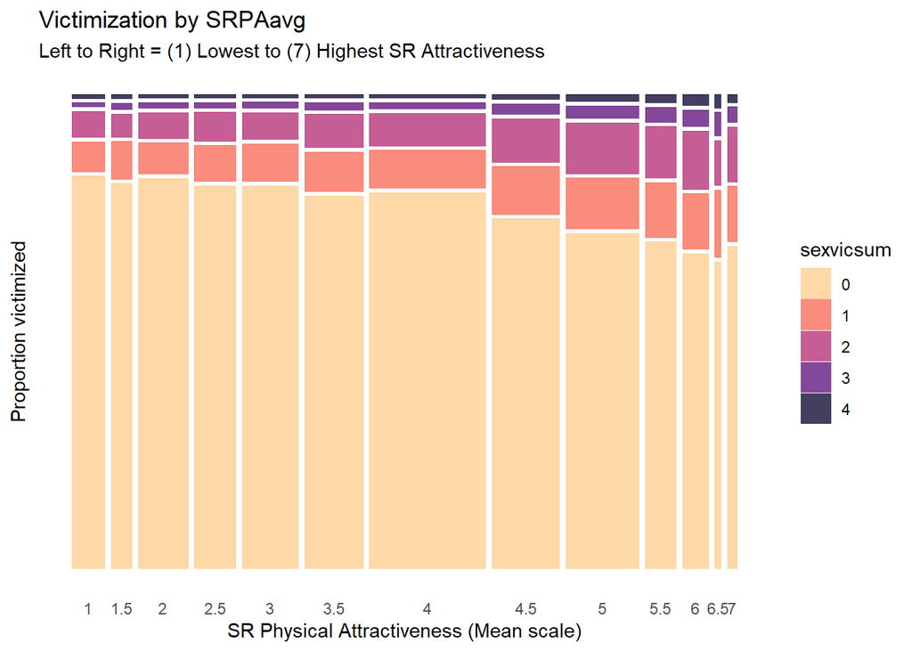

```r
#Function to quickly generate custom mosaic plots with labels
  # see https://stackoverflow.com/questions/58034811/ggplot2-not-recognizing-a-column-in-a-function-call
  # for help with passing column names to ggplot in functions

mosyplot <- function(df, yvar, xvar, xlabel, ylabel, mytitle, mysubtitle){
  ggplot() +
  geom_mosaic(data=df, aes(x = product(!!as.name(yvar), !!as.name(xvar)), fill = !!as.name(yvar)),
              na.rm=TRUE) +
  labs(x = xlabel,
       y = ylabel,
       title=mytitle,
       subtitle = mysubtitle) +
  scale_fill_viridis_d(begin=.1, end=.9, direction=-1, option="magma") +
  theme_minimal() +
  theme(panel.grid.major = element_blank(),
        panel.grid.minor = element_blank(),
        axis.text.y = element_blank())
  }

# SRPAavg
mosyx <- mosyplot(df=datv3, "sexvicsum", "SRPAavg", "SR Physical Attractiveness (Mean scale)",
         "Proportion victimized", "Victimization by SRPAavg",
         "Left to Right = (1) Lowest to (7) Highest SR Attractiveness"
)
mosyx
```

**Victimization by SR attractiveness (95 pctl)**

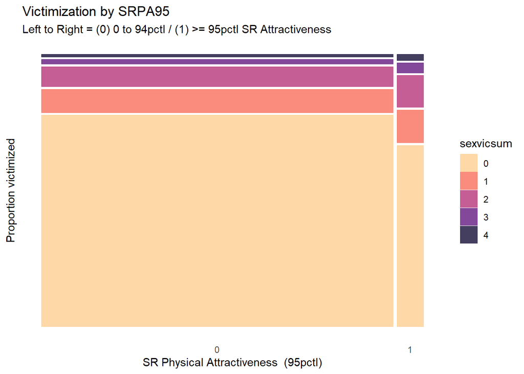

```r
# SRPA95
mosyx95 <- mosyplot(df=datv3, "sexvicsum", "SRPA95", "SR Physical Attractiveness  (95pctl)",
         "Proportion victimized", "Victimization by SRPA95",
         "Left to Right = (0) 0 to 94pctl / (1) >= 95pctl SR Attractiveness"
)
mosyx95
```

**Victimization by sexual activity**